# Topic-8

TA Kiran

2023-11-13

```r
setwd("D:/TA Introducing the data Science/2023 notes/Topic-8")#set the current working directory
getwd()   #get the current working directory
```

```
## [1] "D:/TA Introducing the data Science/2023 notes/Topic-8"
```

**Installing and loading R packages**

**tm** for text mining operations like removing numbers, special characters, punctuations and stop words (Stop words in any language are the most commonly occurring words that have very little value for NLP and should be filtered out. Examples of stop words in English are “the”, “is”, “are”.)

**snowballc** for stemming, which is the process of reducing words to their base or root form. For example, a stemming algorithm would reduce the words “fishing”, “fished” and “fisher” to the stem “fish”.

**wordcloud** for generating the word cloud plot.

**RColorBrewer** for color palettes used in various plots

**syuzhet** for sentiment scores and emotion classification

**ggplot2** for plotting graphs

```r
#install.packages("tm")  # for text mining
#install.packages("SnowballC") # for text stemming
#install.packages("wordcloud") # word-cloud generator
#install.packages("RColorBrewer") # color palettes
#install.packages("syuzhet") # for sentiment analysis
#install.packages("ggplot2") # for plotting graphs
# Load
library("tm")
library("SnowballC")
library("wordcloud")
library("RColorBrewer")
library("syuzhet")
library("ggplot2")
```

Reading the text dataset

**Virtual Corpus (VCorpus):** This is a container provided by the tm package to manage and manipulate a collection of text documents. It’s called “virtual” because it doesn’t load the complete text of all documents into memory at once, which can be important when dealing with large datasets. It allows you to access and process documents selectively.

***DirSource:** This is a source in tm that reads in a collection of text documents from a specified directory. It’s particularly useful when you have multiple text documents stored in a folder, and you want to analyze them collectively.

```r
# Specify the directory path
cname = file.path('trump_speech\\')
# Create a virtual corpus(VCorpus) using DirSource
docs <- VCorpus(DirSource(cname))  # 'docs' is a VCorpus that represents the collection of documents in the specified directory
summary(docs)
```

```
##                                               Length Class             Mode
## Trump Black History Month Speech.txt          2      PlainTextDocument list
## Trump CIA Speech.txt                          2      PlainTextDocument list
## Trump Congressional Address.txt               2      PlainTextDocument list
## Trump CPAC Speech.txt                         2      PlainTextDocument list
## Trump Florida Rally 2-18-17.txt               2      PlainTextDocument list
## Trump Immigration Speech 8-31-16.txt          2      PlainTextDocument list
## Trump Inauguration Speech.txt                 2      PlainTextDocument list
## Trump National Prayer Breakfast.txt           2      PlainTextDocument list
## Trump Nomination Speech.txt                   2      PlainTextDocument list
## Trump Police Chiefs Speech.txt                2      PlainTextDocument list
## Trump Response to Healthcare Bill Failure.txt 2      PlainTextDocument list
```

```r
#"inspect" is a useful function for exploring the structure and content of your text data during the initial stages of a text mining project.
inspect(docs[1])
```

```
## <<VCorpus>>
## Metadata:  corpus specific: 0, document level (indexed): 0
## Content:  documents: 1
##
## [[1]]
## <<PlainTextDocument>>
## Metadata:  7
## Content:  chars: 3974
```

```r
writeLines(as.character(docs[1]))
```

```
## list(list(content = c("Well, the election, it came out really well. Next time we’ll triple the number or quadruple it. We want to get it over 51, right? At least 51.", "", "Well this is Black History Month, so this is our little breakfast, our little get-together. Hi Lynn, how are you? Just a few…
## "", "Last month, we celebrated the life of Reverend Martin Luther King, Jr., whose incredible example is unique in American history. You read all about Dr. Martin Luther King a week ago when somebody said I took the statue out of my office. It turned out that that was fake news. Fake news. The st…
## "", "I am very proud now that we have a museum on the National Mall where people can learn about Reverend King, so many other things. Frederick Douglass is an example of somebody who’s done an amazing job and is being recognized more and more, I noticed. Harriet Tubman, Rosa Parks, and millions m…
## "", "We’re gonna need better schools and we need them soon. We need more jobs, we need better wages, a lot better wages. We’re gonna work very hard on the inner city. Ben is gonna be doing that, big league. That’s one of the big things that you’re gonna be looking at. We need safer communities an…
## "", "I’m ready to do my part, and I will say this: We’re gonna work together. This is a great group, this is a group that’s been so special to me. You really helped me a lot. If you remember I wasn’t going to do well with the African-American community, and after they heard me speaking and talkin…
## "", "So I want to thank everybody for being here."), meta = list(author = character(0), datetimestamp = list(sec = 3.27800107002258, min = 35, hour = 15, mday = 14, mon = 10, year = 123, wday = 2, yday = 317, isdst = 0), description = character(0), heading = character(0), id = "Trump Black Histor…
## list()
## list()
```

**Cleaning up Text Data**

-The tm_map() function in the ‘tm’ package is used to apply various text transformations to a corpus.

```r
### Data preprocessing
# Remove Punctuation(.,?...)
docs <- tm_map(docs,removePunctuation)
writeLines(as.character(docs[1])) # Check to see if it worked.
```

```
## list(list(content = c("Well the election it came out really well Next time we’ll triple the number or quadruple it We want to get it over 51 right At least 51", "", "Well this is Black History Month so this is our little breakfast our little gettogether Hi Lynn how are you Just a few notes During…
## "", "Last month we celebrated the life of Reverend Martin Luther King Jr whose incredible example is unique in American history You read all about Dr Martin Luther King a week ago when somebody said I took the statue out of my office It turned out that that was fake news Fake news The statue is c…
## "", "I am very proud now that we have a museum on the National Mall where people can learn about Reverend King so many other things Frederick Douglass is an example of somebody who’s done an amazing job and is being recognized more and more I noticed Harriet Tubman Rosa Parks and millions more bl…
## "", "We’re gonna need better schools and we need them soon We need more jobs we need better wages a lot better wages We’re gonna work very hard on the inner city Ben is gonna be doing that big league That’s one of the big things that you’re gonna be looking at We need safer communities and we’re …
## "", "I’m ready to do my part and I will say this We’re gonna work together This is a great group this is a group that’s been so special to me You really helped me a lot If you remember I wasn’t going to do well with the AfricanAmerican community and after they heard me speaking and talking about …
## "", "So I want to thank everybody for being here"), meta = list(author = character(0), datetimestamp = list(sec = 3.27800107002258, min = 35, hour = 15, mday = 14, mon = 10, year = 123, wday = 2, yday = 317, isdst = 0), description = character(0), heading = character(0), id = "Trump Black History…
## list()
## list()
```

```r
#removing special characters from the text. This is done using the tm_map() function to replace special characters like /, @ and | with a space.
#Remove ascii character
for (j in seq(docs)){
   docs[[j]] <- gsub("/", " ", docs[[j]])
   docs[[j]] <- gsub("@", " ", docs[[j]])
   docs[[j]] <- gsub("\\|", " ", docs[[j]])
   docs[[j]] <- gsub('e2\u0080e ', " ", docs[[j]])
   docs[[j]] <- gsub('e2\u0080', " ", docs[[j]])
   docs[[j]] <- gsub("e2\u2028e", " ", docs[[j]])
   docs[[j]] <- gsub("e2\u2028", " ", docs[[j]])
   docs[[j]] <- gsub("\u0080 ", " ", docs[[j]])# This is an ascii character that did not translate, so it had to be removed.
}
writeLines(as.character(docs[1])) # You can check a document (in this case
```

```
## list(c("Well the election it came out really well Next time we’ll triple the number or quadruple it We want to get it over 51 right At least 51", "", "Well this is Black History Month so this is our little breakfast our little gettogether Hi Lynn how are you Just a few notes During this month we …
## "", "Last month we celebrated the life of Reverend Martin Luther King Jr whose incredible example is unique in American history You read all about Dr Martin Luther King a week ago when somebody said I took the statue out of my office It turned out that that was fake news Fake news The statue is c…
## "", "I am very proud now that we have a museum on the National Mall where people can learn about Reverend King so many other things Frederick Douglass is an example of somebody who’s done an amazing job and is being recognized more and more I noticed Harriet Tubman Rosa Parks and millions more bl…
## "", "We’re gonna need better schools and we need them soon We need more jobs we need better wages a lot better wages We’re gonna work very hard on the inner city Ben is gonna be doing that big league That’s one of the big things that you’re gonna be looking at We need safer communities and we’re …
## "", "I’m ready to do my part and I will say this We’re gonna work together This is a great group this is a group that’s been so special to me You really helped me a lot If you remember I wasn’t going to do well with the AfricanAmerican community and after they heard me speaking and talking about …
## "", "So I want to thank everybody for being here"))
## list()
## list()
```

```r
#??? Remove number and Converting to lowercase
docs <- tm_map(docs, removeNumbers)
docs <- tm_map(docs, tolower)#to ensure consistency in text analysis, as it treats uppercase and lowercase letters as equivalent.
docs <- tm_map(docs, PlainTextDocument)
DocsCopy <- docs
writeLines(as.character(docs[1])) # Check to see if it worked
```

```
## list(list(content = c("well the election it came out really well next time we’ll triple the number or quadruple it we want to get it over  right at least ", "", "well this is black history month so this is our little breakfast our little gettogether hi lynn how are you just a few notes during thi…
## "", "last month we celebrated the life of reverend martin luther king jr whose incredible example is unique in american history you read all about dr martin luther king a week ago when somebody said i took the statue out of my office it turned out that that was fake news fake news the statue is c…
## "", "i am very proud now that we have a museum on the national mall where people can learn about reverend king so many other things frederick douglass is an example of somebody who’s done an amazing job and is being recognized more and more i noticed harriet tubman rosa parks and millions more bl…
## "", "we’re gonna need better schools and we need them soon we need more jobs we need better wages a lot better wages we’re gonna work very hard on the inner city ben is gonna be doing that big league that’s one of the big things that you’re gonna be looking at we need safer communities and we’re …
## "", "i’m ready to do my part and i will say this we’re gonna work together this is a great group this is a group that’s been so special to me you really helped me a lot if you remember i wasn’t going to do well with the africanamerican community and after they heard me speaking and talking about …
## "", "so i want to thank everybody for being here"), meta = list(author = character(0), datetimestamp = list(sec = 3.60636591911316, min = 35, hour = 15, mday = 14, mon = 10, year = 123, wday = 2, yday = 317, isdst = 0), description = character(0), heading = character(0), id = character(0), langua…
## list()
## list()
```

-removing numbers, converting to lowercase, and potentially converting to plain text. These steps are common in text mining to standardize and clean the text data before further analysis.

**Remove the stopwords.** They are the most commonly occurring words in a language and have very little value in terms of gaining useful information. They should be removed before performing further analysis. Examples of stopwords in English are “the, is, at, on”.

```r
## Remove english common stopwords
docs <- tm_map(docs, removeWords, stopwords("english"))
docs <- tm_map(docs, PlainTextDocument)
writeLines(as.character(docs[1])) # Check to see if it worked.
```

```
## list(list(content = c("well  election  came  really well next time ’ll triple  number  quadruple   want  get    right  least ", "", "well   black history month     little breakfast  little gettogether hi lynn    just   notes   month  honor  tremendous history  africanamericans throughout  country…
## "", "last month  celebrated  life  reverend martin luther king jr whose incredible example  unique  american history  read   dr martin luther king  week ago  somebody said  took  statue    office  turned     fake news fake news  statue  cherished ’s one   favorite things  —    good ones   lincoln…
## "", "’m proud  honor  heritage  will  honoring      folks   table  almost  cases   great friends  supporters darrell— met darrell    defending   television   people      side   argument didn’t   chance right  paris  done  amazing job    hostile cnn community ’s    ’ll  seven people  paris  ’ll ta…
## "", "’m ready    part   will say  ’re gonna work together    great group    group ’s   special    really helped   lot   remember  wasn’t going   well   africanamerican community    heard  speaking  talking   inner city  lots   things  ended  getting—  won’t go  details—  ended  getting substantia…
## "", "  want  thank everybody   "), meta = list(author = character(0), datetimestamp = list(sec = 3.72551894187927, min = 35, hour = 15, mday = 14, mon = 10, year = 123, wday = 2, yday = 317, isdst = 0), description = character(0), heading = character(0), id = character(0), language = character(0)…
## list()
## list()
```

```r
# Remove your own stop word
# specify your custom stopwords as a character vector
docs <- tm_map(docs, removeWords, c("syllogism", "tautology")) # removing specific words
```

```r
# Combining words that should stay together
for (j in seq(docs)) {
  docs[[j]] <- gsub("fake news", "fake_news", docs[[j]])   #Replace "fake news" with "fake_news":
  docs[[j]] <- gsub("inner city", "inner-city", docs[[j]]) #Replace "inner city" with "inner-city":
  docs[[j]] <- gsub("politically correct", "politically_correct", docs[[j]])  #Replace "politically correct" with "politically_correct"
}
docs <- tm_map(docs, PlainTextDocument)
writeLines(as.character(docs[1])) # Check to see if it worked.
```

```
## list(list(content = c("well  election  came  really well next time ’ll triple  number  quadruple   want  get    right  least ", "", "well   black history month     little breakfast  little gettogether hi lynn    just   notes   month  honor  tremendous history  africanamericans throughout  country…
## "", "last month  celebrated  life  reverend martin luther king jr whose incredible example  unique  american history  read   dr martin luther king  week ago  somebody said  took  statue    office  turned     fake_news fake_news  statue  cherished ’s one   favorite things  —    good ones   lincoln…
## "", "’m proud  honor  heritage  will  honoring      folks   table  almost  cases   great friends  supporters darrell— met darrell    defending   television   people      side   argument didn’t   chance right  paris  done  amazing job    hostile cnn community ’s    ’ll  seven people  paris  ’ll ta…
## "", "’m ready    part   will say  ’re gonna work together    great group    group ’s   special    really helped   lot   remember  wasn’t going   well   africanamerican community    heard  speaking  talking   inner-city  lots   things  ended  getting—  won’t go  details—  ended  getting substantia…
## "", "  want  thank everybody   "), meta = list(author = character(0), datetimestamp = list(sec = 3.80899095535278, min = 35, hour = 15, mday = 14, mon = 10, year = 123, wday = 2, yday = 317, isdst = 0), description = character(0), heading = character(0), id = character(0), language = character(0)…
## list()
## list()
```

-These modifications help standardize certain phrases and can be useful in text mining tasks where maintaining consistency in the representation of specific terms is important. If you find that these substitutions align with your objectives, they can contribute to a more uniform and analytically meaningful representation of your text data.

**The last step is text stemming.** It is the process of reducing the word to its root form. The stemming process simplifies the word to its common origin. For example, the stemming process reduces the words “fishing”, “fished” and “fisher” to its stem “fish”.

Stemming is a common text preprocessing technique, but it’s important to note that it may not always be appropriate for all NLP tasks. Stemming algorithms reduce words to their base form, but they may also introduce errors or produce results that are not actual words. It’s a trade-off between simplifying the vocabulary and potentially losing some precision in the representation of words.

If stemming aligns with the goals of your text mining project and the characteristics of your data, then this preprocessing step can contribute to a more streamlined and consistent representation of words.

```r
#Removing stem word
docs_st <- tm_map(docs, stemDocument)
docs_st <- tm_map(docs_st, PlainTextDocument)
writeLines(as.character(docs_st[1])) # Check to see if it worked.
```

```
## list(list(content = c("well elect came realli well next time ’ll tripl number quadrupl want get right least", "", "well black histori month littl breakfast littl gettogeth hi lynn just note month honor tremend histori africanamerican throughout countri throughout world realli think right stori on…
## "", "last month celebr life reverend martin luther king jr whose incred exampl uniqu american histori read dr martin luther king week ago somebodi said took statu offic turn fake_new fake_new statu cherish ’s one favorit thing — good one lincoln jefferson dr martin luther king said statu bust mar…
## "", "’m proud honor heritag will honor folk tabl almost case great friend support darrell— met darrel defend televis peopl side argument didn’t chanc right pari done amaz job hostil cnn communiti ’s ’ll seven peopl pari ’ll take pari seven don’t watch cnn don’t get see much use don’t like watch f…
## "", "’m readi part will say ’re gonna work togeth great group group ’s special realli help lot rememb wasn’t go well africanamerican communiti heard speak talk inner-c lot thing end getting— won’t go details— end get substanti candid run past year now ’re gonna take new level want thank televis s…
##     author = character(0), datetimestamp = list(sec = 3.88326096534729, min = 35, hour = 15, mday = 14, mon = 10, year = 123, wday = 2, yday = 317, isdst = 0), description = character(0), heading = character(0), id = character(0), language = character(0), origin = character(0))))
## list()
## list()
```

- From the above stemming words it introduced some error or produced results that are not actual words. so , we will not use this step in the per processing step.

```r
# Stripping unnecessary whitespace
docs <- tm_map(docs, stripWhitespace)
writeLines(as.character(docs[1])) # Check to see if it worked.
```

```
## list(list(content = c("well election came really well next time ’ll triple number quadruple want get right least ", "", "well black history month little breakfast little gettogether hi lynn just notes month honor tremendous history africanamericans throughout country throughout world really think…
## "", "last month celebrated life reverend martin luther king jr whose incredible example unique american history read dr martin luther king week ago somebody said took statue office turned fake_news fake_news statue cherished ’s one favorite things — good ones lincoln jefferson dr martin luther ki…
## "", "’m proud honor heritage will honoring folks table almost cases great friends supporters darrell— met darrell defending television people side argument didn’t chance right paris done amazing job hostile cnn community ’s ’ll seven people paris ’ll take paris seven don’t watch cnn don’t get see…
## "", "’m ready part will say ’re gonna work together great group group ’s special really helped lot remember wasn’t going well africanamerican community heard speaking talking inner-city lots things ended getting— won’t go details— ended getting substantially candidates run past years now ’re gonn…
## "", " want thank everybody "), meta = list(author = character(0), datetimestamp = list(sec = 3.80899095535278, min = 35, hour = 15, mday = 14, mon = 10, year = 123, wday = 2, yday = 317, isdst = 0), description = character(0), heading = character(0), id = character(0), language = character(0), or…
## list()
## list()
```

```r
# Finish preprocessing
docs <- tm_map(docs, PlainTextDocument)
writeLines(as.character(docs[1])) # Check to see if it worked.
```

```
## list(list(content = c("well election came really well next time ’ll triple number quadruple want get right least ", "", "well black history month little breakfast little gettogether hi lynn just notes month honor tremendous history africanamericans throughout country throughout world really think…
## "", "last month celebrated life reverend martin luther king jr whose incredible example unique american history read dr martin luther king week ago somebody said took statue office turned fake_news fake_news statue cherished ’s one favorite things — good ones lincoln jefferson dr martin luther ki…
## "", "’m proud honor heritage will honoring folks table almost cases great friends supporters darrell— met darrell defending television people side argument didn’t chance right paris done amazing job hostile cnn community ’s ’ll seven people paris ’ll take paris seven don’t watch cnn don’t get see…
## "", "’m ready part will say ’re gonna work together great group group ’s special really helped lot remember wasn’t going well africanamerican community heard speaking talking inner-city lots things ended getting— won’t go details— ended getting substantially candidates run past years now ’re gonn…
## "", " want thank everybody "), meta = list(author = character(0), datetimestamp = list(sec = 3.97279095649719, min = 35, hour = 15, mday = 14, mon = 10, year = 123, wday = 2, yday = 317, isdst = 0), description = character(0), heading = character(0), id = character(0), language = character(0), or…
## list()
## list()
```

**Building the term document matrix**

```r
### Tesxt Mining
# Build a term-document matrix
dtm <- DocumentTermMatrix(docs)  #n this matrix, rows correspond to documents, and columns correspond to terms (words). The entries in the matrix represent the frequency of each term in each document.
dtm
```

```
## <<DocumentTermMatrix (documents: 11, terms: 3659)>>
## Non-/sparse entries: 8364/31885
## Sparsity           : 79%
## Maximal term length: 19
## Weighting          : term frequency (tf)
```

```r
dt=as.matrix(dtm)  #converts the Document-Term Matrix (dtm) to a regular matrix (dt

#Print Dimensions of the Matrix:
dim(as.matrix(dtm))
```

```
## [1]   11 3659
```

From the above result

*Documents:* There are 11 documents in your corpus.

*Sparsity:* The sparsity of the matrix is 79%. Sparsity is a measure of how many entries in the matrix are zero. In this case, 79% of the entries are zero, indicating that the matrix is sparse, which is common in text data.

*Maximal term length:* The longest term (word) in the matrix has a length of 19 characters.

*Weighting* The matrix is weighted using term frequency (tf). Term frequency represents how often a term occurs in a document. Other weighting schemes, such as term frequency-inverse document frequency (TF-IDF), are also commonly used in text mining.

```r
# Terms frequency
freq <- colSums(as.matrix(dtm))
length(freq)
```

```
## [1] 3659
```

```r
freq
```

[output not shown]

[output cut: 1775 more lines]

[output not shown]

```r
# Start by removing sparse terms
dtms <- removeSparseTerms(dtm, 0.2) # This makes a matrix that is 20% empty space, maximum.
dtms
```

```
## <<DocumentTermMatrix (documents: 11, terms: 87)>>
## Non-/sparse entries: 848/109
## Sparsity           : 11%
## Maximal term length: 11
## Weighting          : term frequency (tf)
```

```r
freq <- colSums(as.matrix(dtms))
length(freq)
```

```
## [1] 87
```

```r
freq
```

```
##        also      always     america    american     another        back
##          54          24         122         107          22          75
##         bad     believe         big        came         can        care
##          35          60          45          20         100          37
##        come     country         day   different        done enforcement
##          55         174          36          16          24          43
##        even        ever       every         get     getting        give
##          55          42          49          79          23          25
##       going        good       great       group      happen         job
##         265          58         163          20          36          38
##        just        know        last         law         let        life
##          88         127          44          59          40          27
##        like      little        long        look         lot        love
##          79          24          36          52          44          45
##        made        many        much        must      nation        need
##          32         101          68          53          48          32
##       never         new         now      office         one      people
##          83          69         111          24         139         278
##   president         put      really    remember       right        safe
##          44          35          57          27         102          35
##        said         say         see        seen   something     special
##          83          66          48          34          25          26
##      states        take        tell       thank      things       think
##          65          64          50         105          40          77
##        time       today    together     totally       truly  understand
##          76          33          34          18          16          29
##      united        want         way        well        will        work
##          64         140          71          51         428          64
##       world        year       years
##          56          47          54
```

```r
# Most and least frequently occurring words (TOP 14)
## Sort by descearing value of frequency
freq <- sort(colSums(as.matrix(dtm)), decreasing=TRUE)
head(freq, 20)  # Display the top 20 terms
```

```
##     will   people    going  country    great     want      one     know
##      428      278      265      174      163      140      139      127
##  america      now american    thank    right     many      can   theyre
##      122      111      107      105      102      101      100       89
##     just    never     said      get
##       88       83       83       79
```

```r
tail(freq, 20)  # Display the bottom 20 terms
```

```
##       wish   withdraw  witnessed witnessing     womens    wonders    workout
##          1          1          1          1          1          1          1
##     worlds      worth    wouldve    wounded        wow   writings      wrote
##          1          1          1          1          1          1          1
##       yeah   yearsold yesterdays       youd   youngest       zone
##          1          1          1          1          1          1
```

```r
findFreqTerms(dtm, lowfreq=50) # Change "50" to whatever is most appropriate for your text data.
```

```
##  [1] "’re"         "also"        "america"     "american"    "back"
##  [6] "believe"     "can"         "come"        "country"     "dont"
## [11] "even"        "get"         "going"       "good"        "great"
## [16] "immigration" "jobs"        "just"        "know"        "law"
## [21] "like"        "look"        "make"        "many"        "much"
## [26] "must"        "never"       "new"         "now"         "one"
## [31] "people"      "really"      "right"       "said"        "say"
## [36] "states"      "take"        "tell"        "thank"       "theyre"
## [41] "think"       "time"        "united"      "want"        "way"
## [46] "well"        "will"        "work"        "world"       "years"
```

```r
wf <- data.frame(word=names(freq), freq=freq)
head(wf)
```

```
##            word freq
## will       will  428
## people   people  278
## going     going  265
## country country  174
## great     great  163
## want       want  140
```

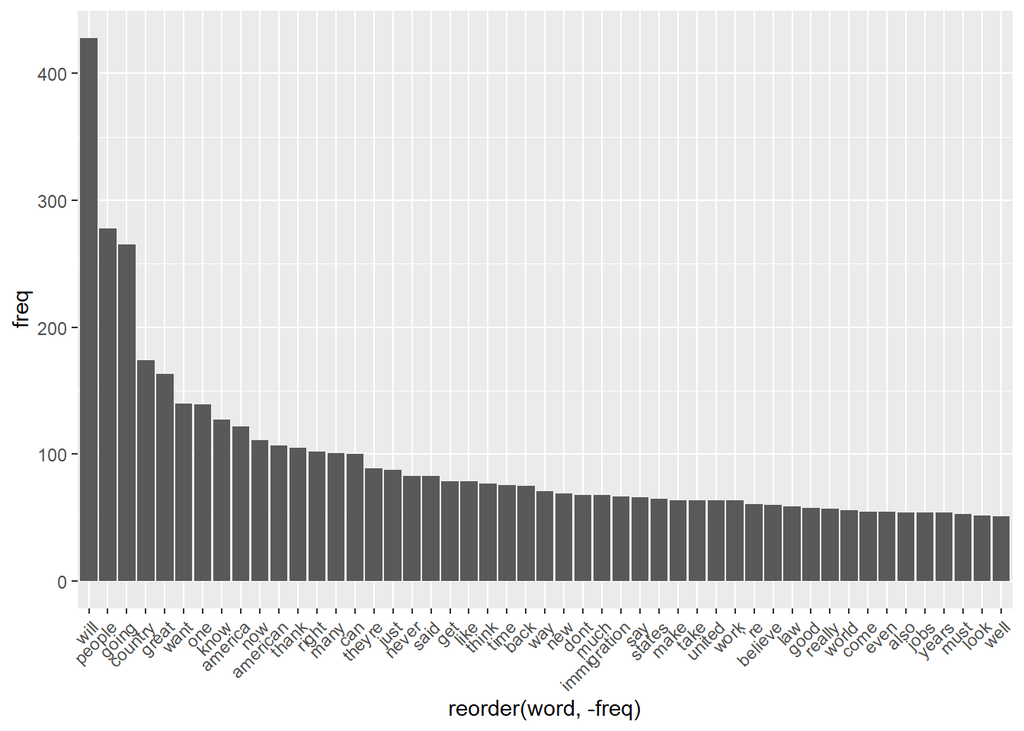

```r
# Plot words that appear at least 50 times
library(ggplot2)
p <- ggplot(subset(wf, freq>50), aes(x = reorder(word, -freq), y = freq)) +
 geom_bar(stat = "identity") +
 theme(axis.text.x=element_text(angle=45, hjust=1))
p
```

**Word Association**

- Correlation is a statistical technique that can demonstrate whether, and how strongly, pairs of variables are related. This technique can be used effectively to analyze which words occur most often in association with the most frequently occurring words in the survey responses, which helps to see the context around these words

```r
# Term Correlations
findAssocs(dtms, "think", corlimit=0.70) # specifying a correlation limit of 0.7
```

```
## $think
## really   well   care    lot happen    see   good
##   0.89   0.88   0.86   0.76   0.72   0.72   0.71
```

This script shows which words are most frequently associated with the term “think” (corlimit = 0.70 is the lower limit/threshold I have set. You can set it lower to see more words, or higher to see less).

```r
# Find associations
findAssocs(dtms, terms = c("good","work","years"), corlimit = 0.80)
```

```
## $good
##    even     get getting believe     bad   great     way    look     lot
##    0.92    0.91    0.84    0.83    0.82    0.82    0.82    0.81    0.81
##
## $work
## united
##   0.83
##
## $years
##     take     also      one     came remember   people     back  country
##     0.93     0.92     0.87     0.85     0.85     0.84     0.83     0.82
##      put  believe    never
##     0.82     0.81     0.80
```

**Generate the Word Cloud**

A word cloud is one of the most popular ways to visualize and analyze qualitative data. It’s an image composed of keywords found within a body of text, where the size of each word indicates its frequency in that body of text.

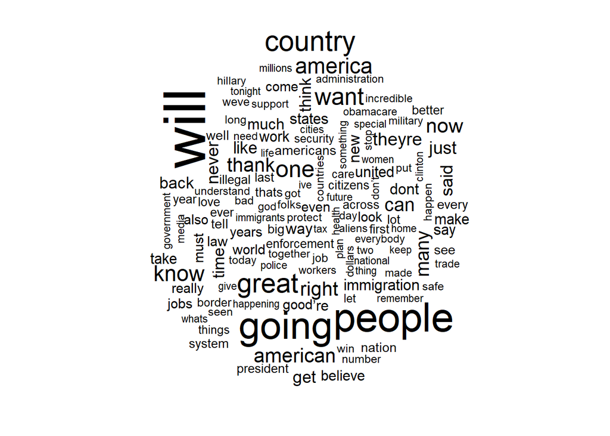

```r
# Word Cloud
library(wordcloud)
set.seed(142) #fix the words position on wordcloud.
wordcloud(names(freq), freq, min.freq=25) #min.freq – words whose frequency is at or above this threshold value is plotted
```

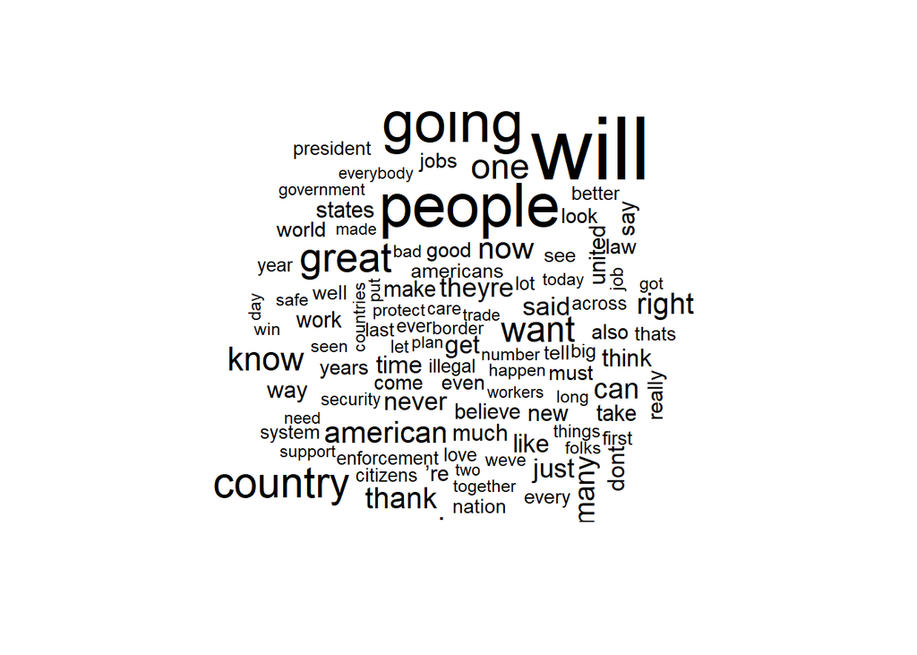

```r
set.seed(142)
wordcloud(names(freq), freq, max.words=100) #the maximum number of words to display on the plot
```

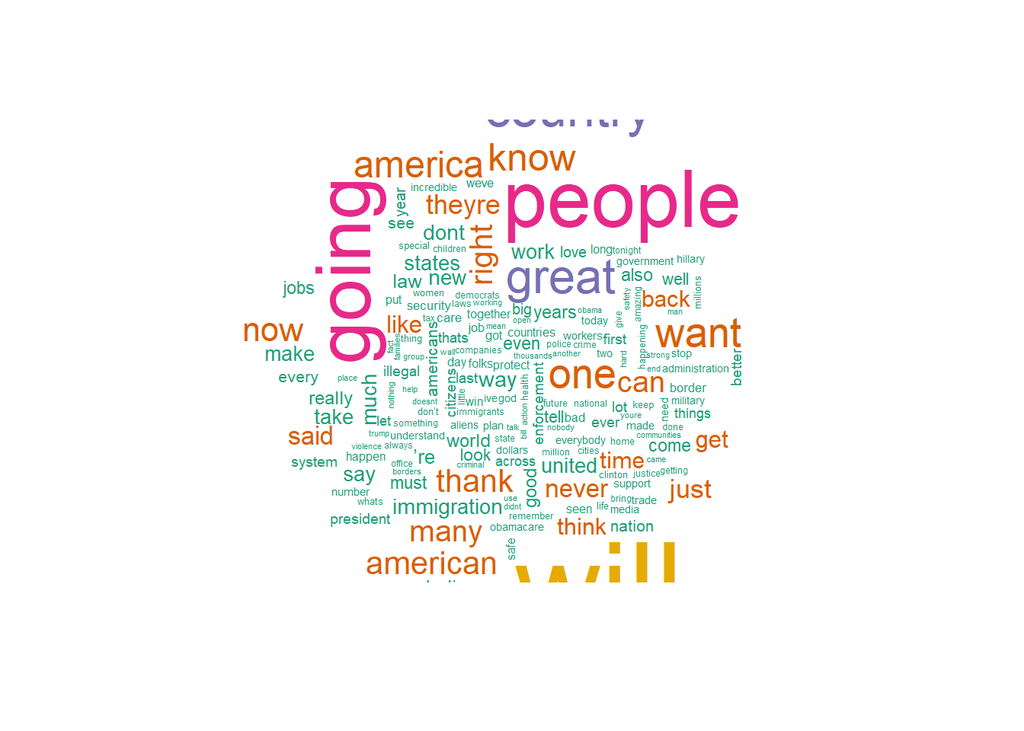

```r
set.seed(142)
wordcloud(names(freq), freq, min.freq=20, scale=c(5, .1), colors=brewer.pal(6, "Dark2")) # changes word colors going from lowest to highest frequencies
```

**Clustering**

```r
### Clustering
#Remove uninteresting or infrequent words
dtmss <- removeSparseTerms(dtm, 0.15) # This makes a matrix that is only 15% empty space, maximum.
dtmss
```

```
## <<DocumentTermMatrix (documents: 11, terms: 43)>>
## Non-/sparse entries: 452/21
## Sparsity           : 4%
## Maximal term length: 9
## Weighting          : term frequency (tf)
```

```r
# Hierarchal Clustering
library(cluster)
## Assuming dtms is the correct Document-Term Matrix
d <- dist(t(dtmss), method="euclidian")  #Computes the Euclidean distance matrix for the transposed
fit <- hclust(d=d, method="complete") # for a different look try substituting: method="ward.D"
# Display the hierarchical clustering structure
fit
```

```
##
## Call:
## hclust(d = d, method = "complete")
##
## Cluster method   : complete
## Distance         : euclidean
## Number of objects: 43
```

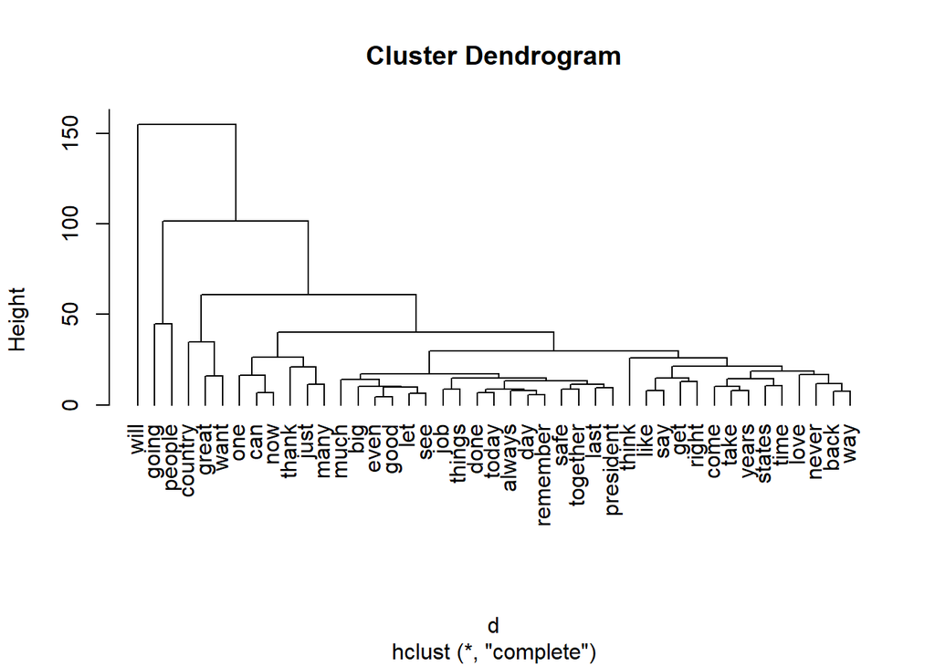

```r
plot(fit, hang=-1)
```

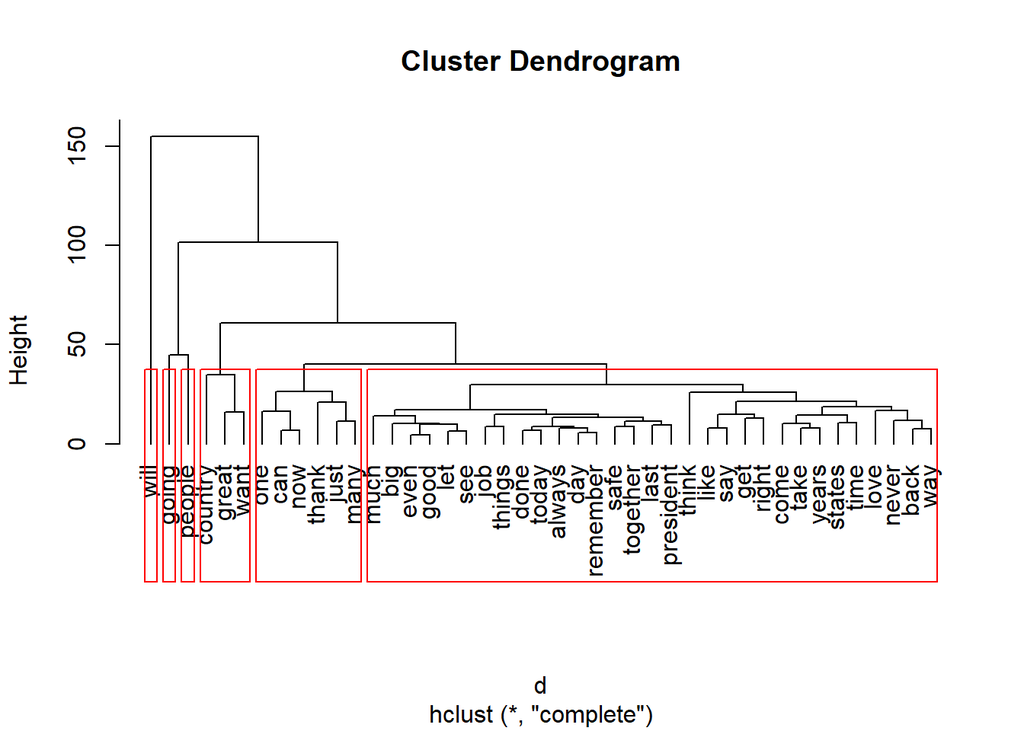

```r
# Helping to Read a Dendrogram
plot.new()
plot(fit, hang=-1)
groups <- cutree(fit, k=6) # "k=" defines the number of clusters you are using
rect.hclust(fit, k=6, border="red") # draw dendogram with red borders around the 6 clusters
```

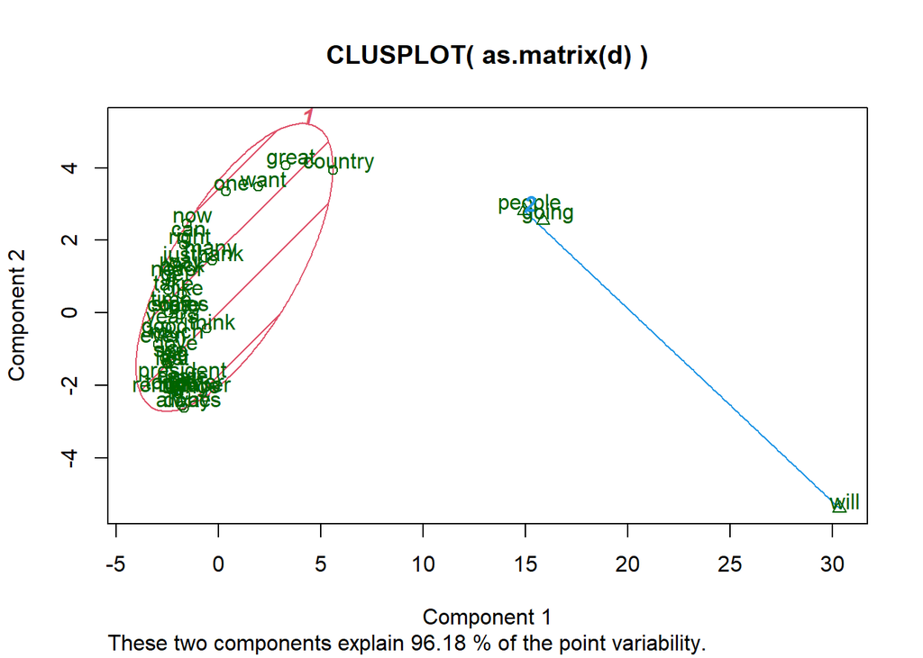

```r
# ??? K-means clustering
library(fpc)
d <- dist(t(dtmss), method="euclidian")
kfit <- kmeans(d, 2)
clusplot(as.matrix(d), kfit$cluster, color=T, shade=T, labels=2, lines=0)
```

**Classification**

- we are reading the dataset call text_sentoken

```r
### Classification
# Preprocessing:
source = DirSource('txt_sentoken\\',recursive=T)
corpus = Corpus(source)
dtm = DocumentTermMatrix(corpus,control = list(weighting = weightTfIdf,
                                                 stopwords = T, removePunctuation = T,
                                                 stemming = T))
#Convert the Document-Term Matrix (dtm) to a data frame
x.df = as.data.frame(as.matrix(dtm))
# Display the dimensions of the data frame
dim(x.df)
```

```
## [1]  2000 31236
```

```r
# Add a column for the class labels (assuming 0 for the first 1000 documents and 1 for the next 1000)
x.df$class_label = c(rep(0,1000),rep(1,1000))
# Create an index to sample 300 rows for testing
index = sample(1:1000,300)
# Create the training set (excluding the sampled rows) and the test set (including the sampled rows)
train = x.df[-c(index,index+1000),]
test = x.df[c(index,index+1000),]
# Display the table of class labels in the training set
table(train$class_label)
```

```
##
##   0   1
## 700 700
```

```r
# Find terms with a minimum IDF of 4 and add 'class_label' to the selected terms
s = findFreqTerms(dtm,4)#the lower bound value of  minimum IDF (nverse Document Frequency) is 4
s = c(s,'class_label')
s
```

```
##   [1] "act"         "action"      "actor"       "actual"      "alien"
##   [6] "also"        "although"    "american"    "anim"        "anoth"
##  [11] "audienc"     "back"        "bad"         "becom"       "best"
##  [16] "better"      "big"         "brother"     "can"         "cast"
##  [21] "charact"     "come"        "comedi"      "day"         "direct"
##  [26] "director"    "doesnt"      "dont"        "effect"      "end"
##  [31] "enough"      "even"        "everi"       "famili"      "feel"
##  [36] "film"        "final"       "find"        "first"       "friend"
##  [41] "funni"       "get"         "girl"        "give"        "good"
##  [46] "great"       "guy"         "happen"      "hes"         "high"
##  [51] "horror"      "howev"       "human"       "interest"    "isnt"
##  [56] "john"        "just"        "kid"         "kill"        "know"
##  [61] "last"        "laugh"       "life"        "like"        "littl"
##  [66] "live"        "long"        "look"        "lot"         "love"
##  [71] "made"        "make"        "man"         "mani"        "may"
##  [76] "men"         "minut"       "moment"      "movi"        "much"
##  [81] "music"       "name"        "never"       "new"         "now"
##  [86] "old"         "origin"      "part"        "peopl"       "perform"
##  [91] "pictur"      "play"        "plot"        "point"       "problem"
##  [96] "real"        "realli"      "right"       "role"        "run"
## [101] "say"         "scene"       "script"      "see"         "seem"
## [106] "seen"        "set"         "show"        "someth"      "star"
## [111] "start"       "still"       "stori"       "take"        "that"
## [116] "there"       "thing"       "think"       "though"      "time"
## [121] "tri"         "turn"        "two"         "use"         "want"
## [126] "war"         "watch"       "way"         "well"        "wife"
## [131] "will"        "woman"       "work"        "world"       "year"
## [136] "young"       "class_label"
```

**Logistic Regression**

```r
# Logistic Regression:
# Fit a logistic regression model
model.glm = glm(class_label ~ ., train[,s],family="binomial")
# Display the coefficients of the model
coef(model.glm)
```

```
##  (Intercept)          act       action        actor       actual        alien
##   -0.1100705   -9.0174578   -8.1188908  -20.6192796  -16.6972014    6.9860143
##         also     although     american         anim        anoth      audienc
##   84.9610524   57.7535001   47.6714671   19.1355842   -0.5062912   -3.9518532
##         back          bad        becom         best       better          big
##   61.0815282 -166.4609348   10.3192333   36.3106090  -47.6083248   -9.0538430
##      brother          can         cast      charact         come       comedi
##  -25.8033548  -44.3428358    3.8179988  -37.8239561  -41.2622274   -9.0540135
##          day       direct     director       doesnt         dont       effect
##   16.7577716   20.5044211  -41.0514430   -2.9109937  -23.6283359    1.2374694
##          end       enough         even        everi       famili         feel
##   -5.1236686  -25.0238942 -113.7958594    5.5901907   26.1445104   28.2605742
##         film        final         find        first       friend        funni
##    5.6030700   36.8460863   22.2396426   42.7549832   12.9572970  -11.1883671
##          get         girl         give         good        great          guy
##   12.7809414   -6.3225831    3.5137678   50.9789395   77.2705204   37.6785885
##       happen          hes         high       horror        howev        human
##   -9.9627051   -7.2023675    9.9070827   17.4424459    0.2105467   10.7943513
##     interest         isnt         john         just          kid         kill
##  -18.2762591  -23.4745706   -5.6505276  -43.6860242   -9.7045482  -36.5886442
##         know         last        laugh         life         like        littl
##   22.8842479   -7.9961435   21.1769022   42.2273273 -102.0058141  -34.9927540
##         live         long         look          lot         love         made
##  -22.5908118  -45.1272067 -101.3578851   19.3227857   28.3105596  -35.0539788
##         make          man         mani          may          men        minut
##   46.4149316    9.0379559   36.6536534    0.8625778   20.8225931  -43.5664654
##       moment         movi         much        music         name        never
##    4.8105316  -46.3037534   12.4738191    9.3339932    1.7957464   12.8345175
##          new          now          old       origin         part        peopl
##   39.9447224  -16.5647136  -17.0572255  -41.8478351  -31.4973373   10.9708295
##      perform       pictur         play         plot        point      problem
##   84.6098485   37.9816816  -28.0286009  -74.7527420  -27.5934945  -56.1841406
##         real       realli        right         role          run          say
##    3.5792352   12.6686904   35.4071086   13.3837230   32.5110682   22.0140317
##        scene       script          see         seem         seen          set
##   -8.9852007  -59.8469612   81.4344295  -44.5039310   46.9816872   -7.7732521
##         show       someth         star        start        still        stori
##   17.9210394   14.3104302    9.1614088   14.5127270    8.1626980   16.5962060
##         take         that        there        thing        think       though
##   27.8249648   -4.5861539  -57.9561933   28.6976200  -26.3843892   19.7535453
##         time          tri         turn          two          use         want
##   14.6969654  -44.3566208   20.5887876   -5.7333716   -0.1780125  -38.3903442
##          war        watch          way         well         wife         will
##   27.3574475   -8.9477412   53.2444606   82.7715797    1.0942361   28.6398317
##        woman         work        world         year        young
##  -28.1048670   21.0268715   26.2983497   12.7819380   -1.2598168
```

```r
# Predict probabilities on the test set
p <- predict(model.glm, test, type = "response")
# Convert probabilities to binary predictions using a threshold of 0.5
labels <- ifelse(p > 0.5, "1", "0")
# Create a confusion table
tab=table('predict'=labels,'real'=test$class_label);tab
```

```
##        real
## predict   0   1
##       0 211  82
##       1  89 218
```

```r
# Calculate the accuracy of the model
sum(diag(tab))/sum(tab)
```

```
## [1] 0.715
```

**Support Vector Machine**

```r
#Support Vector Machine:
library(e1071)
# Define lists of values for the hyperparameters gamma and cost that will be used in the hyperparameter tuning process.
gamma_list <- 2 ^ seq(-20, 20, 4)
cost_list <- 2 ^ seq(-10, 10, 4)
# Tune the SVM model to find optimal hyperparameters
model.svm = tune.svm(class_label ~., data = train[,s],kernel = "radial",gamma = gamma_list, cost=cost_list)#Use the tune.svm function to find the optimal combination of hyperparameters (gamma and cost) for the radial kernel SVM.
model.svm
```

```
##
## Parameter tuning of 'svm':
##
## - sampling method: 10-fold cross validation
##
## - best parameters:
##       gamma cost
##  0.00390625 0.25
##
## - best performance: 0.1849411
```

```r
# Fit an SVM model with specific hyperparameters
model_svm = svm(class_label ~., data = train[,s],kernel = "radial",gamma = 0.00390625,cost = 0.25)
model_svm
```

```
##
## Call:
## svm(formula = class_label ~ ., data = train[, s], kernel = "radial",
##     gamma = 0.00390625, cost = 0.25)
##
##
## Parameters:
##    SVM-Type:  eps-regression
##  SVM-Kernel:  radial
##        cost:  0.25
##       gamma:  0.00390625
##     epsilon:  0.1
##
##
## Number of Support Vectors:  1334
```

```r
# Predict on the test set
p.svm = ifelse(predict(model_svm,newdata = test) < 0.5,0,1)
tab=table('predict'=p.svm,'real'=test$class_label);tab
```

```
##        real
## predict   0   1
##       0 220  82
##       1  80 218
```

```r
# Calculate the accuracy of the SVM model
sum(diag(tab))/sum(tab)
```

```
## [1] 0.73
```